This Jupyter notebook compares the performance of a graph having one time a binary edges between its nodes and other time weighted edges between its nodes using Graph Convolutional Network (Gconv) architecture for node classification task using pytorch and networkx.  
The notebook was implemented by *Nada Chaari*, PhD student at Istanbul Technical University (ITU).

# Table of Contents:

```
1) Application of GCN using Karate dataset with binary edges between the nodes
2) Application of GCN using Karate dataset with weighted edges between the nodes
```

Sources used to build this Jupiter Notebook:

- https://uvadlc-notebooks.readthedocs.io/en/latest/tutorial_notebooks/tutorial7/GNN_overview.html
- https://towardsdatascience.com/how-to-do-deep-learning-on-graphs-with-graph-convolutional-networks-62acf5b143d0
- https://www.pushkarghanekar.com/blog/graph_nn/

# The Spectral Rule

[figure not shown]

source: https://arxiv.org/pdf/2003.11702.pdf

# Application of GCN using Karate dataset

#### Loading Required Libraries

```python
import torch
import matplotlib.pyplot as plt
import torch.nn as nn # create and train neural networks
import torch.optim as optim # optimize the nn using optimization functions
import networkx as nx #  for the creation, manipulation, and study of the structure and functions of complex networks.
from torch_geometric.utils import to_networkx # transfer a geometric dataset object to neworkx graph
from torch_geometric.datasets import KarateClub # for loading the dataset KarateClub
from numpy.random import seed
seed(1)
import numpy as np
import random
torch.manual_seed(0)
```

```
<torch._C.Generator at 0x7f75f0ded1d0>
```

#### Create the convolutional layer

First, we will be creating the GCNConv class, which will serve as the Layer creation class. Every instance of this class will be getting Adjacency Matrix as input and will be outputing 'RELU(A_hat X W)', which the Net class will use.

```python
class GCNConv(nn.Module):
    def __init__(self, A, in_channels, out_channels):
        super(GCNConv, self).__init__()
        self.A_hat = A+torch.eye(A.size(0)) # A(adjacency)+I(identity) [dim = n*n] # indicate that all nodes are self-connected
        self.D     = torch.diag(torch.sum(A,1)) # diagonal of A (nodes degrees) [dim = n*n]
        self.D     = self.D.inverse().sqrt() # D^(-1/2) [dim = n*n]
        self.A_hat = torch.mm(torch.mm(self.D, self.A_hat), self.D) # for normalization to maintain the scale of the output feature vectors [dim = n*n]
        self.W     = nn.Parameter(torch.rand(in_channels,out_channels, requires_grad=True)) #initialization of the weights [dim = in_channels, out_channels]
      # D^(-1/2) * (A+I) * D^(-1/2) *  X  * W

    def forward(self, X):
        out = torch.relu(torch.mm(torch.mm(self.A_hat.double(), X.double()), self.W.double())) # apply activation function (RELU)
        return out
```

#### Create the CGN model using GCN layers

The Net class will combine multiple Conv layer. In our case, the Net class consists of 2 GCN parts to account for the local information. The output of each convolution layer defines the updated nodes features which will be fed to the next convolution layer. Finally, the output of the second convolution layer is a matrix where the raw are the nodes and the columns are scores of belonging to 4 classes.

```python
class Net(torch.nn.Module):
    def __init__(self,A, nfeat, nhid, nout):
        super(Net, self).__init__()
        self.conv1 = GCNConv(A,nfeat, nhid) # nfeat= 34, nhid= 6
        self.conv2 = GCNConv(A,nhid, nout)  # nhid= 6, nhout= 4
    def forward(self,X):
        H  = self.conv1(X) # n is the number of training nodes
                           #          D^(-1/2)*(A+I)*D^(-1/2)* X  *  W
                           # dim(H) =     n*n   n*n    n*n    n*34  34*6  =  [n*6]
        H2 = self.conv2(H) #          D^(-1/2)*(A+I)*D^(-1/2)* H  * W2
                           # dim(H2)=     n*n   n*n    n*n    n*6  6*4  =  [n*4]
        return H2
```

#### Import Dataset

The dataset describes the social interaction of 34 members and the communities that rise from it, 4 in this case. Each members of the club is defined as a node. Each node is connected to other members in the club. This connection would determine the final grouping of the community in 4 separate labels.

Number of graphs: 1

Number of features: 34

Number of classes: 4

# Nodes classification using a binary adjacency matrix

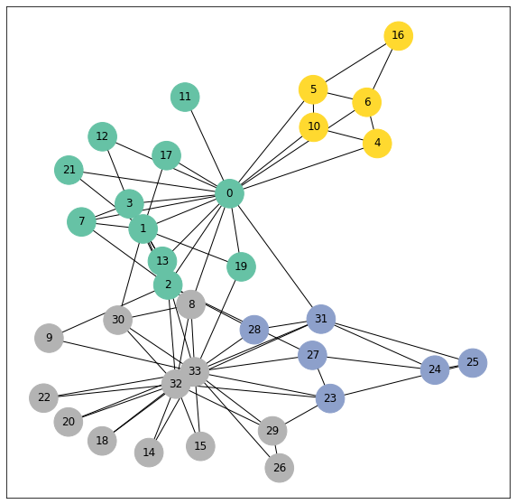

```python
dataset = KarateClub()
G_binary = to_networkx(dataset[0], to_undirected=True)
fig, ax = plt.subplots(1,1,figsize=(10,10))
nx.draw_networkx(G_binary, pos=nx.spring_layout(G_binary, seed=42), node_size=10**3, with_labels=True, node_color=dataset[0].y, cmap="Set2", ax=ax)
Karate_adjacency = torch.Tensor(nx.to_numpy_matrix(G_binary))
```

```python
dataset[0]
```

```
Data(edge_index=[2, 156], train_mask=[34], x=[34, 34], y=[34])
```

```python
dataset[0].x
```

```
tensor([[1., 0., 0.,  ..., 0., 0., 0.],
        [0., 1., 0.,  ..., 0., 0., 0.],
        [0., 0., 1.,  ..., 0., 0., 0.],
        ...,
        [0., 0., 0.,  ..., 1., 0., 0.],
        [0., 0., 0.,  ..., 0., 1., 0.],
        [0., 0., 0.,  ..., 0., 0., 1.]])
```

```python
Karate_adjacency
```

```
tensor([[0., 1., 1.,  ..., 1., 0., 0.],
        [1., 0., 1.,  ..., 0., 0., 0.],
        [1., 1., 0.,  ..., 0., 1., 0.],
        ...,
        [1., 0., 0.,  ..., 0., 1., 1.],
        [0., 0., 1.,  ..., 1., 0., 1.],
        [0., 0., 0.,  ..., 1., 1., 0.]])
```

```python
node_features = dataset[0].x
nhid = 6
nout = 4
# instanciate the GCN model
gcn_model_binary = Net(Karate_adjacency, node_features.size(0), nhid, nout)
# define the CE loss
criterion_binary = torch.nn.CrossEntropyLoss()
# Define the optimizer
optimizer_binary = optim.SGD(gcn_model_binary.parameters(), lr=0.01, momentum=0.9)
```

#### Training the model using Karate dataset

```python
# the training set contains 4 nodes
losses_binary = []
for i in range(5000):
    # forward pass on all the graph
    out_binary = gcn_model_binary(dataset[0].x)
    optimizer_binary.zero_grad() # zero the parameter gradients
    # calculate the loss
    loss_binary = criterion_binary(out_binary[dataset[0].train_mask], dataset[0].y[dataset[0].train_mask])
    loss_binary.backward() # the backward propagates the error (loss) back into the network and update each weight and bias for each layer in the CNN using SGD optimizer
    optimizer_binary.step()  # compute the SGD to find the next
    if i % 1000==0:
        print("Step: {} Cross Entropy Loss = {}".format(i, loss_binary.item()))
        losses_binary.append(loss_binary.item())
        output_binary = gcn_model_binary(dataset[0].x)
```

```
Step: 0 Cross Entropy Loss = 1.6345538720531905
Step: 1000 Cross Entropy Loss = 0.03899958914694151
Step: 2000 Cross Entropy Loss = 0.0119053837115209
Step: 3000 Cross Entropy Loss = 0.0065489131336102
Step: 4000 Cross Entropy Loss = 0.004394175415068611
```

```python
hidden_layer_1_weights = gcn_model_binary.conv1.W
dimension_Hidd_1 = hidden_layer_1_weights.shape
average_1 = torch.mean(hidden_layer_1_weights, 1)
print('dimension of the weights for the first hidden layer =', dimension_Hidd_1)
print('average weights for the first hidden layer =', average_1)
```

```
dimension of the weights for the first hidden layer = torch.Size([34, 6])
average weights for the first hidden layer = tensor([0.7720, 0.8168, 0.5515, 0.7017, 0.4463, 0.3354, 0.5666, 0.5250, 0.8693,
        0.4409, 0.6834, 0.8754, 0.7936, 0.5239, 0.4916, 0.5861, 0.5718, 0.3469,
        0.6073, 0.5681, 0.4663, 0.4443, 0.5468, 0.7796, 0.3605, 0.3677, 0.3978,
        0.3672, 0.6569, 0.4356, 0.8896, 0.6099, 0.4689, 0.5169],
       grad_fn=<MeanBackward1>)
```

```python
hidden_layer_2_weights = gcn_model_binary.conv2.W
dimension_Hidd_2 = hidden_layer_2_weights.shape
average_2 = torch.mean(hidden_layer_2_weights, 1)
print('dimension of the weights for the first hidden layer =', dimension_Hidd_2)
print('average weights for the first hidden layer =', average_2)
```

```
dimension of the weights for the first hidden layer = torch.Size([6, 4])
average weights for the first hidden layer = tensor([0.6157, 0.5899, 0.5487, 0.3875, 0.7053, 0.3783],
       grad_fn=<MeanBackward1>)
```

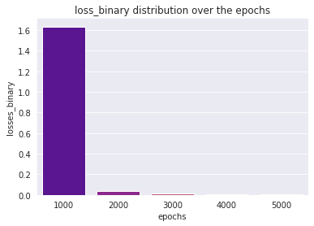

```python
import pandas as pd  # Visualizing Statistical Data
import seaborn as sns # Visualizing Statistical Data
df = pd.DataFrame({'losses_binary': losses_binary, 'epochs': ['1000', '2000', '3000', '4000', '5000']})
sns.set_style('darkgrid')
# plot the accuracy classification for each class
ax = sns.barplot(x ='epochs', y ='losses_binary', data = df, palette ='plasma')
ax.set_title('loss_binary distribution over the epochs')
```

#### Test the model using classification accuracy

```python
# the dataset is divided by default to training (4 nodes) and testing (30 nodes) sets
out_binary[dataset[0].train_mask==False] # the output of the second hidden layer which represent the
                           # scores belonging to 4 classes for each testing nodes for the last epoch
```

```
tensor([[ 7.1188,  0.0000,  0.0000,  9.0984],
        [ 5.0642,  3.5229,  0.0000,  9.9439],
        [ 6.2102,  0.0000,  0.0000,  7.1954],
        [ 7.5605,  0.0000, 14.1882,  0.0000],
        [ 7.5549,  0.0000, 14.2135,  0.0000],
        [ 4.8632,  0.2528,  0.0000,  6.4803],
        [ 2.5846,  2.9268,  0.0000,  8.2149],
        [ 7.0795,  0.0000, 12.5123,  0.0000],
        [10.9841,  0.0000,  3.8437,  5.5943],
        [ 5.8598,  0.0000,  1.0619,  4.4033],
        [ 4.5480,  1.3219,  0.0000,  7.1345],
        [ 1.8318,  4.8229,  0.0000,  7.6227],
        [ 2.2833,  3.9505,  0.0000,  7.9476],
        [ 6.5720,  0.0000, 14.0864,  0.0000],
        [ 5.0865,  0.0000,  0.3552,  4.2595],
        [ 2.2931,  4.3558,  0.0000,  8.0515],
        [ 4.1023,  1.0712,  0.0000,  6.0780],
        [ 2.0770,  4.0113,  0.0000,  7.7636],
        [ 5.2033,  0.0000,  0.0000,  4.8831],
        [ 2.0543,  4.7049,  0.0000,  7.6786],
        [ 0.0000, 11.2324,  0.0000,  1.5231],
        [ 0.0000, 11.3778,  0.0000,  1.3108],
        [ 0.2516,  8.3511,  0.0000,  4.5824],
        [ 0.6959,  8.7039,  0.0000,  4.4678],
        [ 2.0793,  4.8048,  0.0000,  6.3045],
        [ 0.4712,  9.2800,  0.0000,  5.3310],
        [ 3.4559,  2.9796,  0.0000,  9.9029],
        [ 1.6924,  8.9204,  0.0000,  5.2365],
        [ 3.5502,  7.5503,  0.0000, 12.3714],
        [ 4.0138,  9.1813,  0.0000, 13.1634]], dtype=torch.float64,
       grad_fn=<IndexBackward>)
```

```python
test_labels_binary = dataset[0].y[dataset[0].train_mask==False]
test_preds_binary = torch.argmax(out_binary[dataset[0].train_mask==False], dim=1)
# predict the class of each node in the testing set by taking the maximing score
# among the 4 scores assogned for each class for each node by the 2 hidden layer
```

```python
# calculate the classification accuracy of GCN model
correct = 0
for i in range(len(test_preds_binary)):
    if test_preds_binary[i] == test_labels_binary[i]:
        correct+=1
acc_binary = correct/len(test_labels_binary)
print(acc_binary)
```

```
0.7
```

# Nodes classification using a weighted adjacency matrix

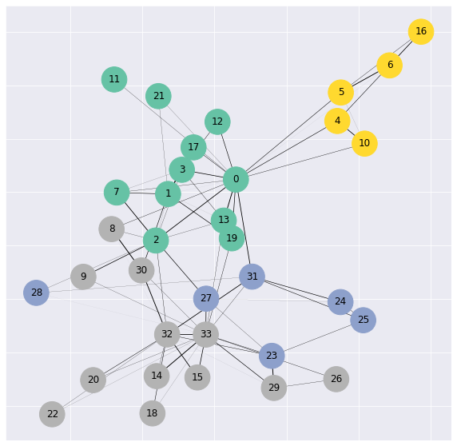

```python
Karate_adjacency = Karate_adjacency.numpy()
np.random.seed(0)
random = np.random.rand(34,34)
weighted_Karate_adjacency = np.multiply(Karate_adjacency,random )

G_weighted = nx.from_numpy_matrix(weighted_Karate_adjacency, parallel_edges=False, create_using=None)
fig, ax = plt.subplots(1,1,figsize=(10,10))
weights = nx.get_edge_attributes(G_weighted,'weight').values()

# Draw the edge labels
nx.draw_networkx(G_weighted, pos=nx.spring_layout(G_weighted, seed=42), node_size=10**3, width=list(weights), with_labels=True, node_color=dataset[0].y,  cmap="Set2", ax=ax)
weighted_Karate_adjacency = torch.Tensor(nx.to_numpy_matrix(G_weighted))
```

```python
weighted_Karate_adjacency
```

```
tensor([[0.0000, 0.0188, 0.8379,  ..., 0.8237, 0.0000, 0.0000],
        [0.0188, 0.0000, 0.0961,  ..., 0.0000, 0.0000, 0.0000],
        [0.8379, 0.0961, 0.0000,  ..., 0.0000, 0.3542, 0.0000],
        ...,
        [0.8237, 0.0000, 0.0000,  ..., 0.0000, 0.8164, 0.2687],
        [0.0000, 0.0000, 0.3542,  ..., 0.8164, 0.0000, 0.8003],
        [0.0000, 0.0000, 0.0000,  ..., 0.2687, 0.8003, 0.0000]])
```

```python
# instanciate the GCN model
gcn_model = Net(weighted_Karate_adjacency, node_features.size(0), nhid, nout)
# define the CE loss
criterion = torch.nn.CrossEntropyLoss()
# Define the optimizer
optimizer = optim.SGD(gcn_model.parameters(), lr=0.01, momentum=0.9)
```

#### Training the model using Karate dataset

```python
# the training set contains 4 nodes
losses = []
for i in range(5000):
    # forward pass on all the graph
    out = gcn_model(dataset[0].x)
    optimizer.zero_grad() # zero the parameter gradients
    # calculate the loss
    loss=criterion(out[dataset[0].train_mask], dataset[0].y[dataset[0].train_mask])
    loss.backward() # the backward propagates the error (loss) back into the network and update each weight and bias for each layer in the CNN using SGD optimizer
    optimizer.step()  # compute the SGD to find the next
    if i % 1000==0:
        print("Step: {} Cross Entropy Loss = {}".format(i, loss.item()))
        losses.append(loss.item())
        output = gcn_model(dataset[0].x)
```

```
Step: 0 Cross Entropy Loss = 1.7036162573587519
Step: 1000 Cross Entropy Loss = 0.005182690181773394
Step: 2000 Cross Entropy Loss = 0.0021016974342599653
Step: 3000 Cross Entropy Loss = 0.001266739234546315
Step: 4000 Cross Entropy Loss = 0.0008908649000031623
```

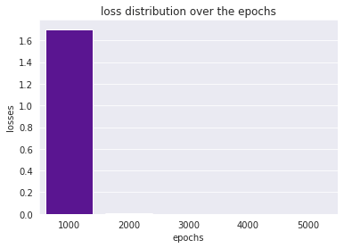

```python
import pandas as pd  # Visualizing Statistical Data
import seaborn as sns # Visualizing Statistical Data
df = pd.DataFrame({'losses': losses, 'epochs': ['1000', '2000', '3000', '4000', '5000']})
sns.set_style('darkgrid')
# plot the accuracy classification for each class
ax = sns.barplot(x ='epochs', y ='losses', data = df, palette ='plasma')
ax.set_title('loss distribution over the epochs')
```

```python
weighted_hidden_layer_1_weights = gcn_model.conv1.W
weighted_dimension_Hidd_1 = weighted_hidden_layer_1_weights.shape
weighted_average_1 = torch.mean(weighted_hidden_layer_1_weights, 1)
print('dimension of the weights for the first hidden layer =', weighted_dimension_Hidd_1)
print('average weights for the first hidden layer =', weighted_average_1)
```

```
dimension of the weights for the first hidden layer = torch.Size([34, 6])
average weights for the first hidden layer = tensor([0.7238, 0.5302, 0.5548, 0.4810, 0.4533, 0.5121, 0.5909, 0.2571, 0.6656,
        0.5854, 0.5506, 0.8527, 0.4608, 0.5261, 0.5365, 0.4915, 0.6755, 0.4932,
        0.7300, 0.7476, 0.5196, 0.5841, 0.4799, 0.4153, 0.4103, 0.7729, 0.7169,
        0.3796, 0.6337, 0.6489, 0.6657, 0.4587, 0.4937, 0.4011],
       grad_fn=<MeanBackward1>)
```

```python
weighted_hidden_layer_2_weights = gcn_model.conv2.W
weighted_dimension_Hidd_2 = weighted_hidden_layer_2_weights.shape
weighted_average_2 = torch.mean(weighted_hidden_layer_2_weights, 1)
print('dimension of the weights for the first hidden layer =', weighted_dimension_Hidd_2)
print('average weights for the first hidden layer =', weighted_average_2)
```

```
dimension of the weights for the first hidden layer = torch.Size([6, 4])
average weights for the first hidden layer = tensor([0.4879, 0.3861, 0.3180, 0.4758, 0.5684, 0.7119],
       grad_fn=<MeanBackward1>)
```

#### Test the model using classification accuracy

```python
# the dataset is divided by default to training (4 nodes) and testing (30 nodes) sets
out[dataset[0].train_mask==False] # the output of the second hidden layer which represent the
                           # scores belonging to 4 classes for each testing nodes for the last epoch
```

```
tensor([[  7.8775,   4.2823,   0.8187,   4.0504],
        [  5.7488,   5.0233,   2.6980,   4.6416],
        [  6.1113,   2.4437,   1.5410,   2.4046],
        [  4.4089,   0.8257,   7.0631,   3.2576],
        [  4.5845,   0.1300,   9.2021,   3.4983],
        [  4.0671,   2.1621,   1.2817,   2.5789],
        [  3.8375,   5.0063,   3.0169,   3.7568],
        [  3.1020,   0.0000,  12.1779,   1.1137],
        [122.0988,  32.4871,   2.7212,  27.8612],
        [  7.0199,   1.6951,   2.8120,   1.7926],
        [  5.0212,   2.7298,   1.4305,   1.8956],
        [  2.6962,   6.5804,   0.0000,   3.4591],
        [  2.4631,   5.3591,   0.2413,   3.0416],
        [  5.0914,   0.3327,   8.5646,   4.0295],
        [  5.2801,   3.3249,   0.0000,   3.5593],
        [  7.5932,   8.2471,   3.4762,   8.1021],
        [  5.0000,   3.6757,   1.4028,   2.4086],
        [  2.6421,   9.7344,   2.8585,   5.3372],
        [ 39.0532,  21.4977,   6.6805,   0.0000],
        [  6.3074,  39.6486,   5.9165,  27.0157],
        [  5.8470,   8.9313,   1.4742,   2.2293],
        [  5.7445,  10.7483,   0.4680,   2.1775],
        [  6.8986,  17.9346,   2.2593,   4.1234],
        [  3.1522,   6.3416,   0.2150,   1.8309],
        [ 22.6843,  19.0402,  12.8694,  19.1886],
        [  3.2790,  12.0659,   0.0000,   2.2375],
        [  2.1574,   2.0665,   0.8335,   8.4676],
        [  6.0375,   7.8803,   2.0810,   3.6653],
        [  4.4636,   9.5541,   1.6642,   7.4835],
        [  5.1156,  11.7854,   0.9213,   5.2654]], dtype=torch.float64,
       grad_fn=<IndexBackward>)
```

```python
test_labels = dataset[0].y[dataset[0].train_mask==False]
test_preds = torch.argmax(out[dataset[0].train_mask==False], dim=1)
```

```python
# calculate the classification accuracy of GCN model
correct = 0
for i in range(len(test_preds)):
    if test_preds[i] == test_labels[i]:
        correct+=1
acc = correct/len(test_labels)
print(acc)
```

```
0.6333333333333333
```

# Comparison between classification accuracy generated by a weighted edges graph and a binary edges graph

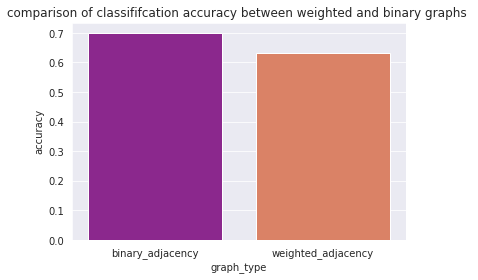

```python
df = pd.DataFrame({'accuracy': [acc_binary,acc], 'graph_type': ['binary_adjacency', 'weighted_adjacency']})
sns.set_style('darkgrid')
# plot the accuracy classification for each type of graphs
ax = sns.barplot(x ='graph_type', y ='accuracy', data = df, palette ='plasma')
ax.set_title('comparison of classififcation accuracy between weighted and binary graphs ')
```

# Comparison between the weights of the $1^{st}$ hidden layer and the average weights over its dimension generated by a weighted edges graph and a binary edges graph

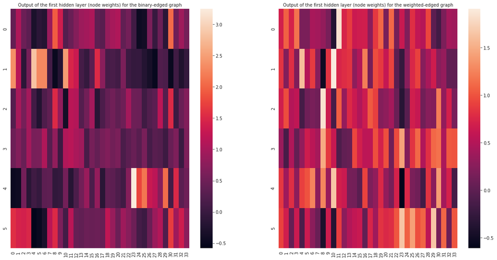

```python
hidden_layer_1_weights = hidden_layer_1_weights.detach().numpy()
hidden_layer_1_weights = np.transpose(hidden_layer_1_weights)
weighted_hidden_layer_1_weights = weighted_hidden_layer_1_weights.detach().numpy()
weighted_hidden_layer_1_weights = np.transpose(weighted_hidden_layer_1_weights)
fig, (ax1, ax2) = plt.subplots(1,2)
fig.set_size_inches(20, 10)
ax1 = sns.heatmap(hidden_layer_1_weights, ax=ax1)
ax1.set_title('Output of the first hidden layer (node weights) for the binary-edged graph', size=10)
ax2 = sns.heatmap(weighted_hidden_layer_1_weights, ax=ax2)
ax2.set_title('Output of the first hidden layer (node weights) for the weighted-edged graph', size=10)
```

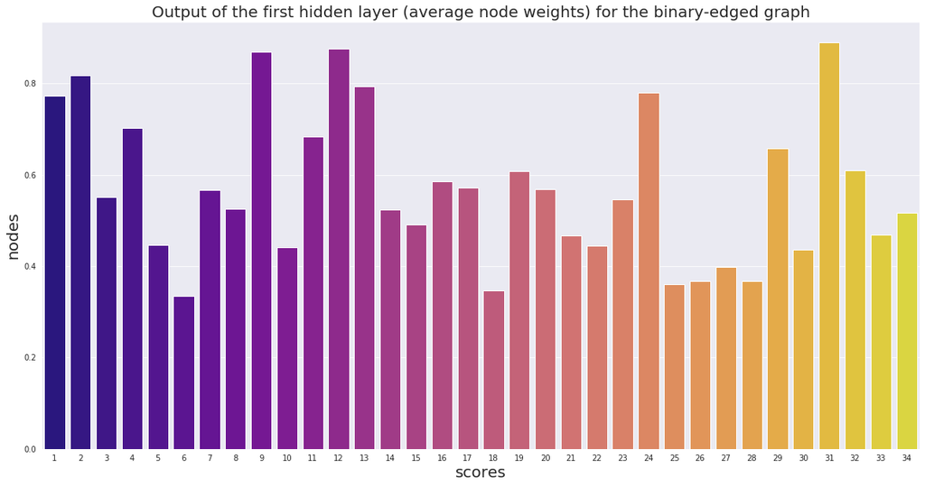

```python
average_1 = average_1.detach().numpy()
fig, ax3 = plt.subplots()
fig.set_size_inches(20, 10)
df = pd.DataFrame({'scores': average_1.tolist(), 'nodes': [i+1 for i in range(34)]})
sns.set_style('darkgrid')
# plot the accuracy classification for each class
ax3 = sns.barplot(x ='nodes', y ='scores', data = df, palette ='plasma')
ax3.set_title('Output of the first hidden layer (average node weights) for the binary-edged graph', size=20)
plt.xlabel("scores", size=20)
plt.ylabel("nodes", size=20)
```

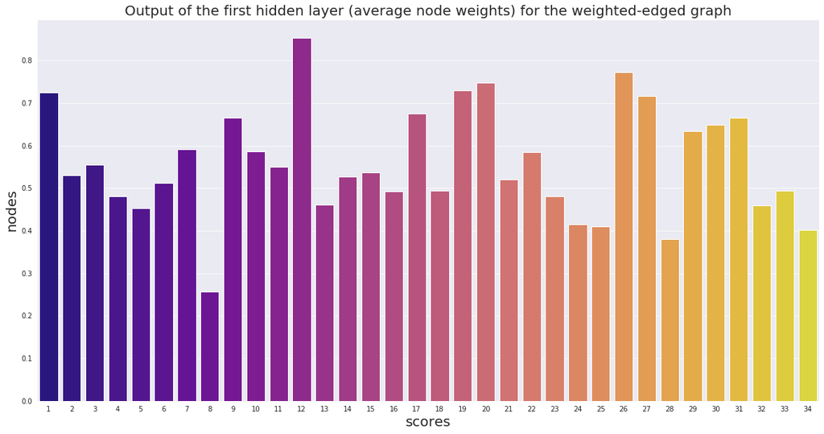

```python
weighted_average_1 = weighted_average_1.detach().numpy()
fig, ax4 = plt.subplots()
fig.set_size_inches(20, 10)
df = pd.DataFrame({'scores': weighted_average_1.tolist(), 'nodes': [i+1 for i in range(34)]})
sns.set_style('darkgrid')
# plot the accuracy classification for each class
ax4 = sns.barplot(x ='nodes', y ='scores', data = df, palette ='plasma')
ax4.set_title('Output of the first hidden layer (average node weights) for the weighted-edged graph', size=20)
plt.xlabel("scores", size=20)
plt.ylabel("nodes", size=20)
```

# Comparison between the weights of the $2^{nd}$ hidden layer and the average weights over its dimension generated by a weighted edges graph and a binary edges graph

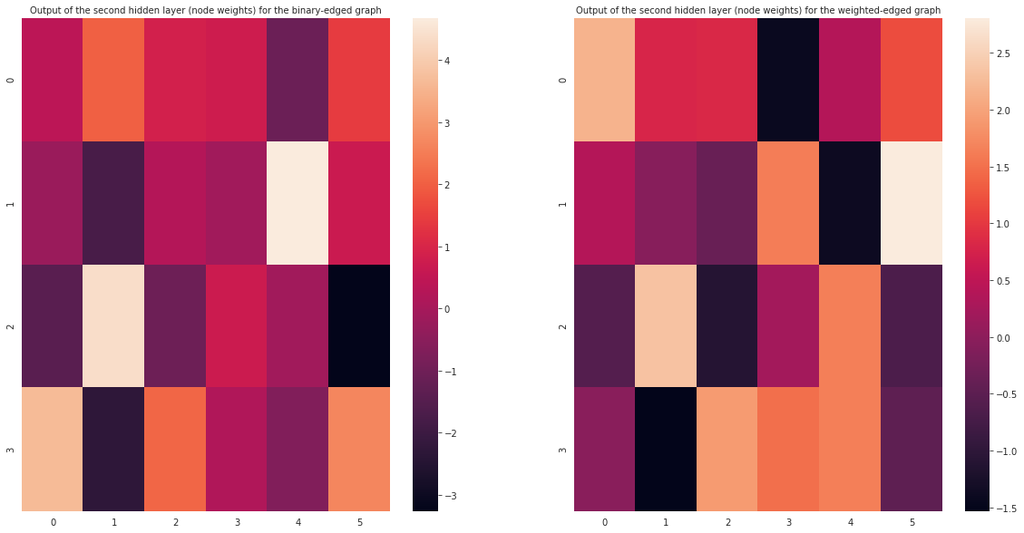

```python
hidden_layer_2_weights = hidden_layer_2_weights.detach().numpy()
hidden_layer_2_weights = np.transpose(hidden_layer_2_weights)
weighted_hidden_layer_2_weights = weighted_hidden_layer_2_weights.detach().numpy()
weighted_hidden_layer_2_weights = np.transpose(weighted_hidden_layer_2_weights)
fig, (ax5, ax6) = plt.subplots(1,2)
fig.set_size_inches(20, 10)
ax5 = sns.heatmap(hidden_layer_2_weights, ax=ax5)
ax5.set_title('Output of the second hidden layer (node weights) for the binary-edged graph', size=10)
ax6 = sns.heatmap(weighted_hidden_layer_2_weights, ax=ax6)
ax6.set_title('Output of the second hidden layer (node weights) for the weighted-edged graph', size=10)
```

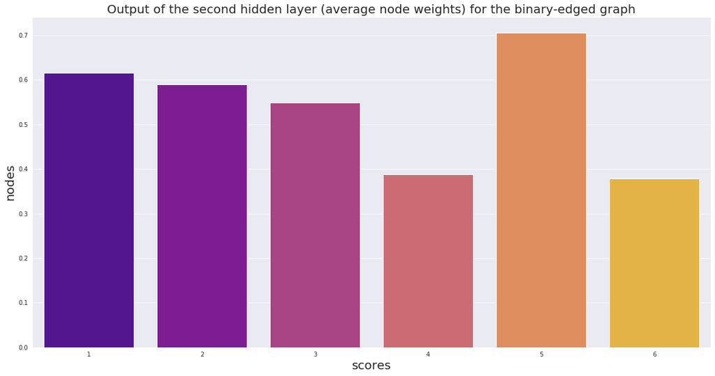

```python
average_2 = average_2.detach().numpy()
fig, ax7 = plt.subplots()
fig.set_size_inches(20, 10)
df = pd.DataFrame({'scores': average_2.tolist(), 'nodes': [i+1 for i in range(6)]})
sns.set_style('darkgrid')
# plot the accuracy classification for each class
ax7 = sns.barplot(x ='nodes', y ='scores', data = df, palette ='plasma')
ax7.set_title('Output of the second hidden layer (average node weights) for the binary-edged graph', size=20)
plt.xlabel("scores", size=20)
plt.ylabel("nodes", size=20)
```

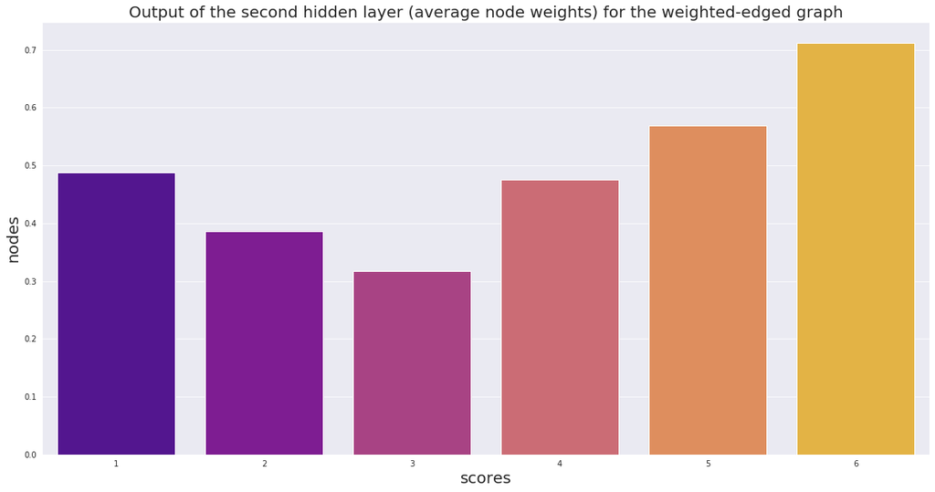

```python
weighted_average_2 = weighted_average_2.detach().numpy()
fig, ax8 = plt.subplots()
fig.set_size_inches(20, 10)
df = pd.DataFrame({'scores': weighted_average_2.tolist(), 'nodes': [i+1 for i in range(6)]})
sns.set_style('darkgrid')
# plot the accuracy classification for each class
ax8 = sns.barplot(x ='nodes', y ='scores', data = df, palette ='plasma')
ax8.set_title('Output of the second hidden layer (average node weights) for the weighted-edged graph', size=20)
plt.xlabel("scores", size=20)
plt.ylabel("nodes", size=20)
```